# Blog

# Add text

To add text use the function **image_annotate**

To add the text in the right bottom use the information from the dimensions above to define the xaxis and yaxis.

[output not shown]

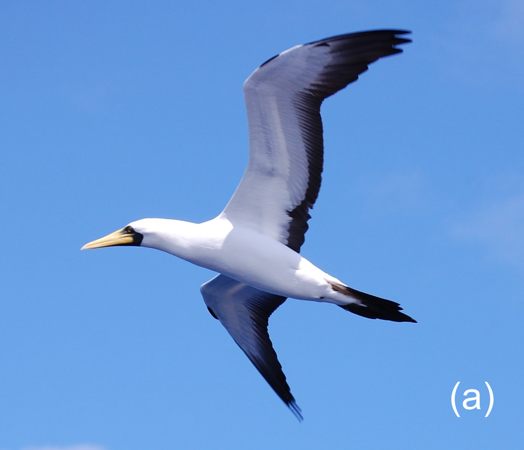

```r
Fig1_text<-image_annotate(Fig1_draw, "(a)",  location = "+1199+999", font = 'Arial', size = 100, color='white')
```

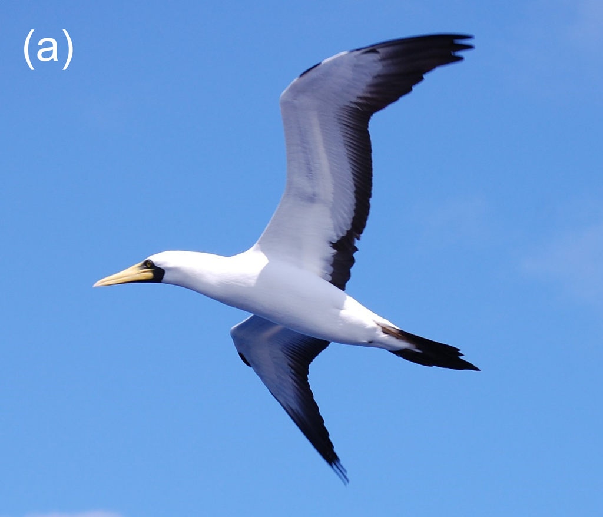

```r
Fig1_text<-image_annotate(Fig1_draw, "(a)",  location = "+50+50", font = 'Arial', size = 100, color='white')
```

# Export

Use the function **image_write** to export.

```r
image_write(Fig1_text, path = paste0(My_directory,"/Fig1_tl.png"), format = "png")
```

# Merge two pictures into one and export

Follow the same steps as above, but with a second picture.

```r
Fig2_draw<-image_draw(Fig2_original)
Fig2_text<-image_annotate(Fig2_draw, "(b)",  location = "+50+50", font = 'Arial', size = 100, color='white')
```

# Add border

Use the function **image_border** to add some space between the pictures.

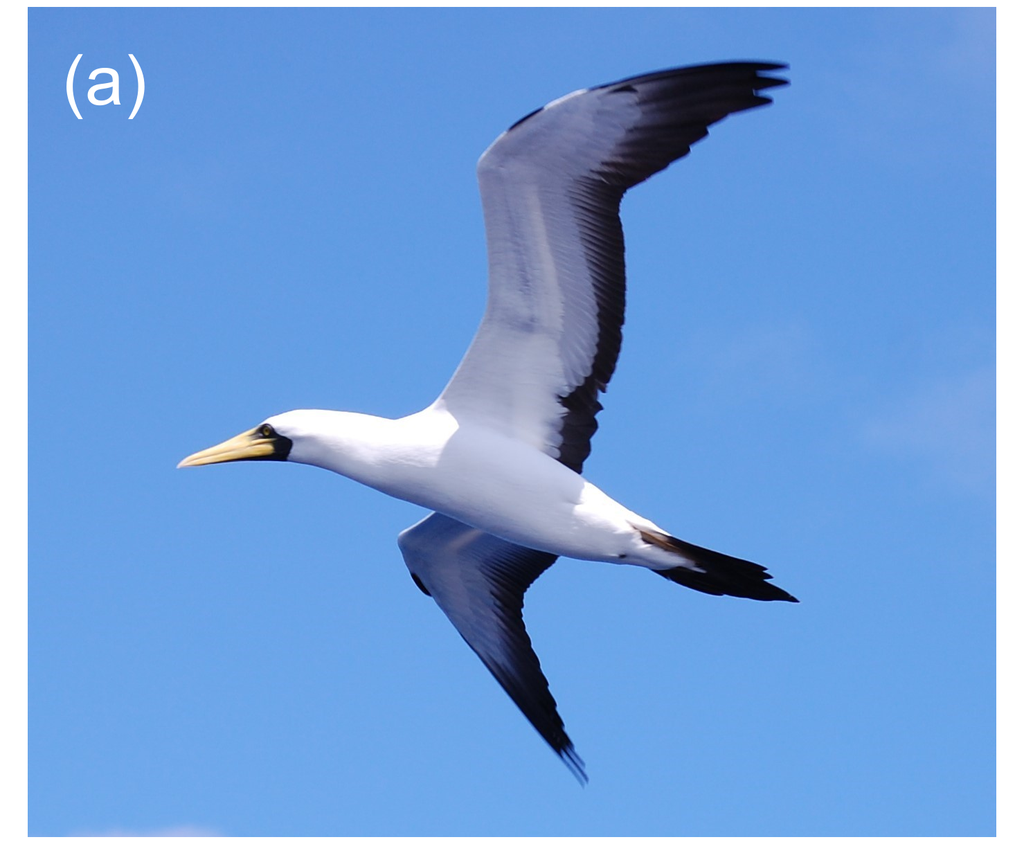

```r
Fig1_border<-image_border(image_background(Fig1_text, "transparent"), "white", "40x10")
Fig1_border
```

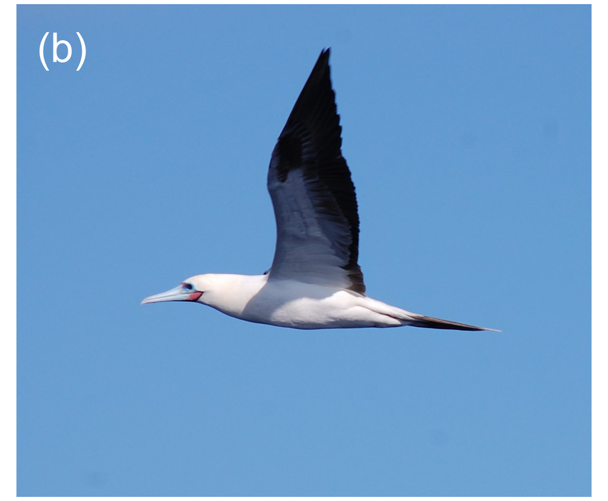

```r
Fig2_border<-image_border(image_background(Fig2_text, "transparent"), "white", "40x10")
Fig2_border
```

# Combine

Use the function **image_append** to have both pictures side by side.

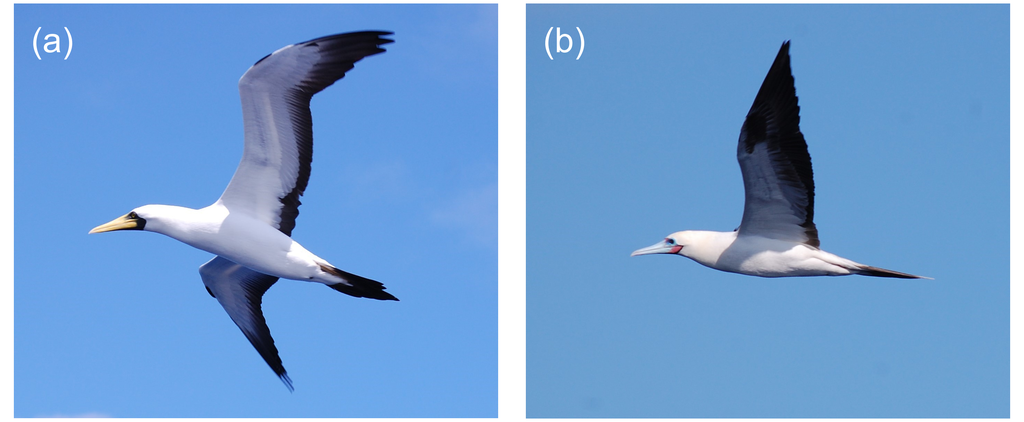

```r
image_append(c(Fig1_border,Fig2_border))
```

# Export

Use the function **image_write** to export the picture.

```r
image_write(image_append(c(Fig1_border,Fig2_border)), path = paste0(My_directory,"/Fig1_append.png"), format = "png")
```

# ~~~~~~~~~~~~~

# 6. June

# Intro

This post is about how to calculate distance from a point

# Data

Identify your reference point

```r
reference<-data.frame(name="reference",lat=54.18,long=7.89)
```

Convert it to a spatial object

```r
reference_sp<-data.frame(lat=reference$lat,
                         lon=reference$lon)
sp::coordinates(reference_sp)<-~lon+lat
```

Then give the information of the other points to compare

```r
colonies_sub<-data.frame(name=c("Ailsa Craig","Barra Head","Bass Rock","Bempton Cliff","Bull Rock","Clare Island", "Fair Isle", "Flannan Isles","Foula","Grassholm Island","Great Saltee", "Helgoland" , "Hermaness", "Ireland’s Eye", "Lambay", "Les Etac/Alderrney","Little Skellig","Mykinesholmur","Noss" ,"Ortac","Rouzic Island","Scar Rocks","St. Kilda","Sula sgeir","Sule Skerry","Sule Stack","Troup Head","Westray"),
colony_lat=c(55.25,56.78,56.08,54.15,51.59,53.80,59.54,58.29,60.13,51.73,52.12,54.18,60.71,53.40,53.49,49.70,51.78,62.10,60.14,49.72,48.90,54.67,57.81,59.10,59.08,59.02,57.69,59.29),
colony_long=c(-5.12,-7.64,-2.64,-0.17,-10.27,-10.00,-1.63,-7.59,-2.07,-5.48,-6.62,7.89,-0.88,-6.06,-6.02,-2.24,-10.51,-7.68,-1.02,-2.29,-3.44,-4.70,-8.56,-6.16,-4.41,-4.51,-2.29,-2.98))
```

```r
head(colonies_sub)
```

```
##            name colony_lat colony_long
## 1   Ailsa Craig      55.25       -5.12
## 2    Barra Head      56.78       -7.64
## 3     Bass Rock      56.08       -2.64
## 4 Bempton Cliff      54.15       -0.17
## 5     Bull Rock      51.59      -10.27
## 6  Clare Island      53.80      -10.00
```

Convert this data frame into a spatial object

```r
colonies_sp<-data.frame(lat=colonies_sub$colony_lat,
                        lon=colonies_sub$colony_long)
sp::coordinates(colonies_sp)<-~lon+lat
```

Give both objects the same coordinate system to make sure they are comparable

```r
sp::proj4string(reference_sp)= sp::CRS("+init=epsg:4326")
sp::proj4string(colonies_sp)= sp::CRS("+init=epsg:4326")
```

# Calculate

Using the funcion **distm** from the package geosphere the distance can be calculated. Give the argument distHaversine. Read here what is [Haversine](https://en.wikipedia.org/wiki/Haversine_formula).

```r
maxdist_m<-(geosphere::distm(reference_sp,colonies_sp,fun = geosphere::distHaversine))
maxdist_km<-round(maxdist_m/1000,digits=2)
```

Load the package **tidyverse** to make some data wrangling

```r
library(tidyverse)
```

Use the function **pivot_longer** to reorder the information

```r
distances<-as.data.frame(maxdist_km)%>%
  pivot_longer(cols=c(V1:V28))
```

Assign to the data frame

```r
colonies_sub$distance<-distances$value
```

Here are the results from the distance between the point and the reference point

```r
head(colonies_sub)
```

```
##            name colony_lat colony_long distance
## 1   Ailsa Craig      55.25       -5.12   843.75
## 2    Barra Head      56.78       -7.64  1019.01
## 3     Bass Rock      56.08       -2.64   701.93
## 4 Bempton Cliff      54.15       -0.17   525.01
## 5     Bull Rock      51.59      -10.27  1249.65
## 6  Clare Island      53.80      -10.00  1168.49
```

# Plot

Load the shapefiles from my package **GermanNorthSea**

```r
library(GermanNorthSea)
```

Transform them to the assigned CRS using the package **sf**

```r
library(sf)
```

Here I used 4326

```r
German_land<-st_transform(GermanNorthSea::German_land, 4326)
German_EEZ<-st_transform(GermanNorthSea::German_EEZ, 4326)
German_SCA<-st_transform(GermanNorthSea::German_natura, 4326)
```

Base plot

To create a plot use **ggplot2**

```r
library(ggplot2)
```

First using a base plot of the North Sea, highlighting the economic exclusive zone of Germany

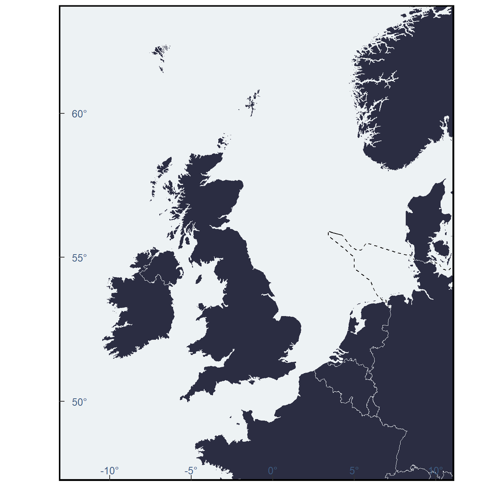

```r
base_plot<-ggplot()+
  geom_sf(data = German_EEZ, colour = "black", fill= NA, lwd = 0.5,linetype="dashed")+
  geom_sf(data = German_land, colour = '#edf2f4', fill = '#2b2d42')+
  coord_sf(xlim = c(-12, 10),ylim = c(48, 63))+
  scale_x_continuous(breaks = c(-10,-5,0,5,10,20,30),labels = function(x) paste0(x, '\u00B0')) +
  scale_y_continuous(breaks = c(45,50,55,60,65,70,75),labels = function(x) paste0(x, '\u00B0'))  +
  theme_bw()+
  xlab('Longitude')+ylab('Latitude')+
  theme(
  panel.background = element_rect(fill = '#edf2f4'),
  panel.grid.major = element_blank(),
  panel.grid.minor = element_blank(),legend.position='none',
  panel.border = element_rect(colour = "black", fill=NA, size=1.5),

  legend.spacing.y = unit(0.05, 'cm'),
  legend.text=element_text(size=10),
  legend.background = element_rect(fill='transparent',colour ="transparent"),
  legend.box.background = element_rect(fill='transparent',colour ="transparent"),
  legend.key = element_rect(fill = "transparent", colour = "transparent"),

  axis.text.x = element_text(size=10,vjust = 10,color='#3d5a80'),
  axis.text.y = element_text(color='#3d5a80',size=10,margin = margin(0,-1.00,0,1, unit = 'cm')),
  axis.title = element_blank(),
  axis.ticks.length=unit(-0.20, "cm"),
  )
base_plot
```

# Plot with curves

Add the reference point to be able to plot

```r
colonies_sub$reference_long<-reference$lon
colonies_sub$reference_lat<-reference$lat
```

Use the function **geom_curve** to create lines between the reference point and the other points.

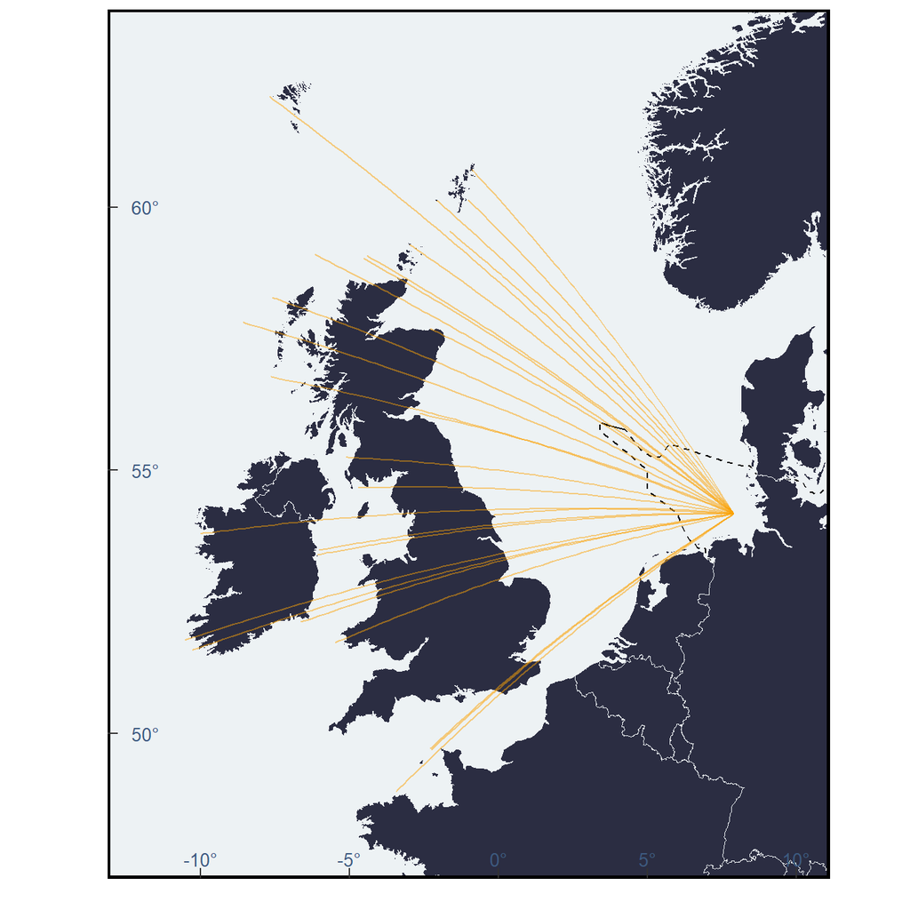

```r
curves_plot<-base_plot+
  geom_curve(data= subset(colonies_sub,colonies_sub$name != 'Helgoland'),
             aes(x = reference_long, y = reference_lat,
                 xend = colony_long, yend = colony_lat),
                 color = '#faa307',
                 curvature = 0.05, alpha = 0.5)
curves_plot
```

Add the other points using **geom_point**

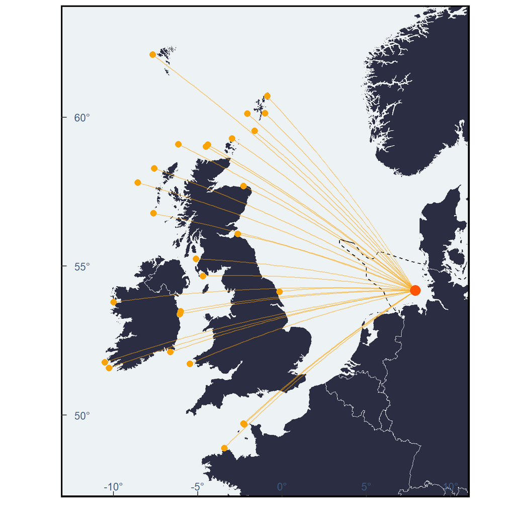

```r
points_plot<-curves_plot+
  geom_point(data=colonies_sub,
             aes(x = colony_long,y= colony_lat),
             color='#faa307', fill='#ffba08',shape=16,size=2,stroke=1.5)+

    geom_point(data=reference,
             aes(x = long,y= lat),
             color='#ff5400', fill='#ff5400',shape=16,size=4,stroke=1.5)
points_plot
```

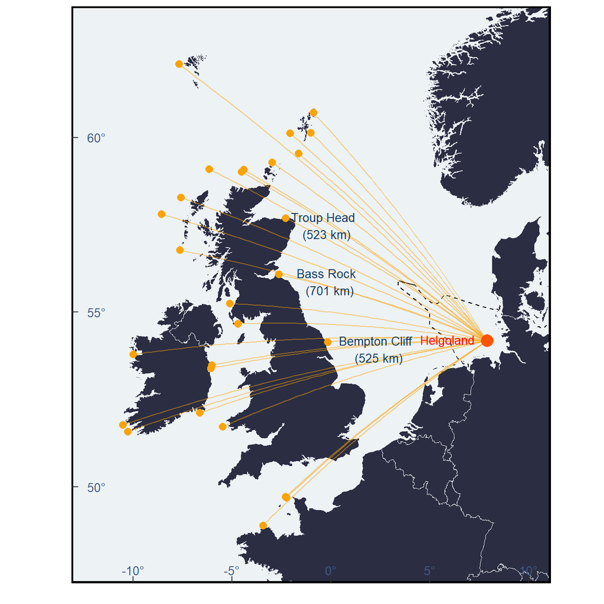

```r
letters_plot<-points_plot+
  annotate("text", y = 54.15-0.21, x = -0.17+2.5,
           label = "Bempton Cliff \n (525 km)",
           size=3.5,color='#0d3b66')+
  annotate("text", y = 56.08-0.21, x = -2.64+2.5,
           label = "Bass Rock \n (701 km)",
           size=3.5,color='#0d3b66')+
  annotate("text", y = 57.69-0.21, x = -2.29+2.0,
           label = "Troup Head \n (523 km)",
           size=3.5,color='#0d3b66')+
  annotate("text", y = 54.18-0.21, x = 7.89-1.9,
           label = "Helgoland \n",
           size=3.5,color='red')+
NULL
letters_plot
```

# Resources

Alternatively using the package [nngeo](https://cran.r-project.org/web/packages/nngeo/index.html)  
Check my package [GermanNorthSea](https://www.miriam-lerma.com/posts/2023-06-02-germannorthsea/)  
How to make maps in R [blogpost](https://www.miriam-lerma.com/posts/2023-03-04-mapping-in-r/)

# Export

# ~~~~~~~~~~~~~

# 7.July

# Interpolate

# Intro

This post is about how to linear interpolate points from a trip

# Data

Download my package **sula** to have access to test data and the function **interpolate_trips**.

```r
#devtools::install_github("MiriamLL/sula")
library(sula)
```

Inside the package, there is data from a tracked individual from Rapa Nui, Chile

```r
ID01_track<-sula::GPS01_trips
```

The data contains Latitude, Longitude, Date, Time, ID and trip_number

```r
head(ID01_track)
```

```
##    Latitude Longitude    DateGMT  TimeGMT   IDs trip trip_number
## 1 -27.23235 -109.4596 02/11/2017 19:34:31 GPS01    Y      trip_1
## 2 -27.23661 -109.4547 02/11/2017 19:38:43 GPS01    Y      trip_1
## 3 -27.24289 -109.4605 02/11/2017 19:42:55 GPS01    Y      trip_1
## 4 -27.24006 -109.4630 02/11/2017 19:47:25 GPS01    Y      trip_1
## 5 -27.24054 -109.4760 02/11/2017 19:51:43 GPS01    Y      trip_1
## 6 -27.25226 -109.4551 02/11/2017 19:56:06 GPS01    Y      trip_1
```

Plot the data using **ggplot** to see whats inside.

```r
library(ggplot2)
```

Add the central location for reference.

```r
ID01_nest<-data.frame(Longitude=-109.4531,Latitude=-27.20097)
```

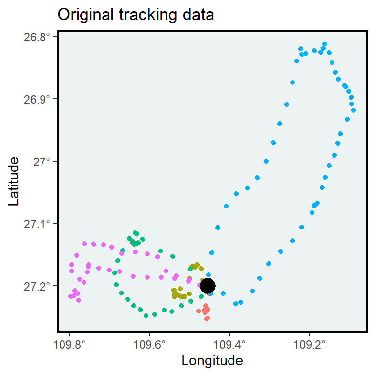

```r
Original_track<-ggplot(ID01_track, aes(x=Longitude, y=Latitude, color=trip_number)) +
  geom_point()+
  theme_bw()+
  ggtitle('Original tracking data')+
  theme_bw()+
  theme(legend.position='none')+
  scale_x_continuous(labels = function(x) paste0(-x, '\u00B0')) +
  scale_y_continuous(labels = function(x) paste0(-x, '\u00B0'))  +
  xlab('Longitude')+ylab('Latitude')+
  theme(
    panel.background = element_rect(fill = '#edf2f4'),
    panel.grid.major = element_blank(),
    panel.grid.minor = element_blank(),legend.position='none',
    panel.border = element_rect(colour = "black", fill=NA, size=1.5)
  )+
  geom_point(data=ID01_nest,aes(x = Longitude,y= Latitude),
             color="black", fill="black",shape=16,size=5,stroke=1.5)
Original_track
```

# Interpolations

For the function, provide the following information:  
1. trip_number, this would separate the trips and interpolate them using a loop. This is important to prevent that locations inside the nest are interpolated.  
2. column_lat, and column_lon, need to be provided with the name of your columns. Here, Latitude and Longitude were the names of my columns. I am providing the Latitude and Longitude in degrees.  
3. column_date, column_time and datetime_format should also be fitting your provided data.  
4. interval, please give the interval in seconds. This interval would depend on the type of data you are providing. Because this is a linear interpolation, be careful to not have large gaps. If you do, I would suggest to remove trips with large gaps before doing the interpolation.

## Interpolate to 1 minute

```r
ID01_interpolated1m<-interpolate_trips(GPS_data=ID01_track,
                                     interval='60 sec',
                                     column_date='DateGMT',
                                     column_time='TimeGMT',
                                     column_trip='trip_number',
                                     column_lat='Latitude',
                                     column_lon='Longitude',
                                     datetime_format<-"%d/%m/%Y %H:%M:%S")
```

You can see that after the function you have more data points.  
This is because the original data was collected every 5 minutes, and the interpolation added locations every one minute.

```r
nrow(ID01_track)
```

```
## [1] 152
```

```r
nrow(ID01_interpolated1m)
```

```
## [1] 615
```

Plot the interpolated data set to see the difference.

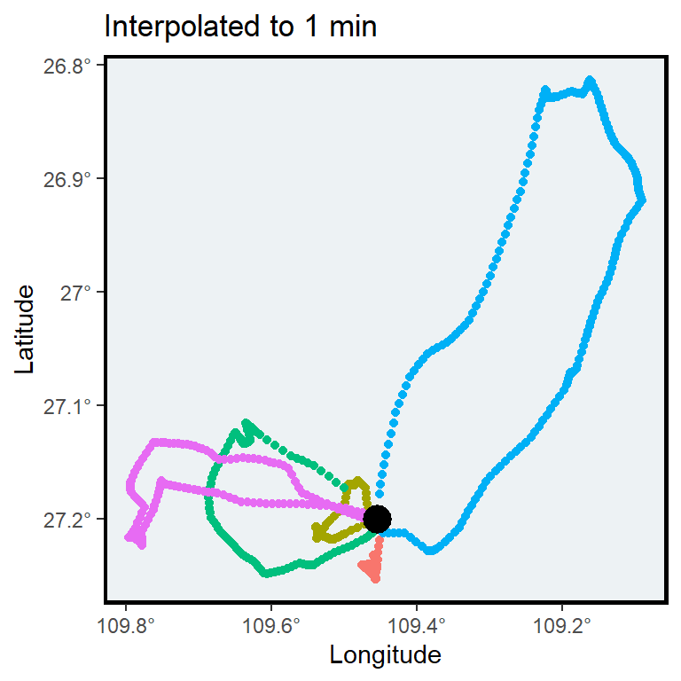

```r
Interpolated_1m<-ggplot(ID01_interpolated1m, aes(x=Longitude, y=Latitude, color=trip_number)) +
  geom_point()+
  ggtitle('Interpolated to 1 min')+
  theme_bw()+
  theme(legend.position='none')+
  scale_x_continuous(labels = function(x) paste0(-x, '\u00B0')) +
  scale_y_continuous(labels = function(x) paste0(-x, '\u00B0'))  +
  xlab('Longitude')+ylab('Latitude')+
  theme(
    panel.background = element_rect(fill = '#edf2f4'),
    panel.grid.major = element_blank(),
    panel.grid.minor = element_blank(),legend.position='none',
    panel.border = element_rect(colour = "black", fill=NA, size=1.5)
  )+
  geom_point(data=ID01_nest,aes(x = Longitude,y= Latitude),
             color="black", fill="black",shape=16,size=5,stroke=1.5)
Interpolated_1m
```

## Interpolate to 15 minutes

To interpolate to 15 minutes, change the interval to 900 sec.

```r
ID01_interpolated15m<-interpolate_trips(GPS_data=ID01_track,
                                     column_trip='trip_number',
                                     column_lat='Latitude',
                                     column_lon='Longitude',
                                     column_date='DateGMT',
                                     column_time='TimeGMT',
                                     datetime_format<-"%d/%m/%Y %H:%M:%S",
                                     interval='900 sec')
```

You can see that after the function you have less data points.  
This is because the original data was collected every 5 minutes, and the interpolation added locations every 15 minutes.

```r
nrow(ID01_track)
```

```
## [1] 152
```

```r
nrow(ID01_interpolated15m)
```

```
## [1] 44
```

Plot to see the difference.

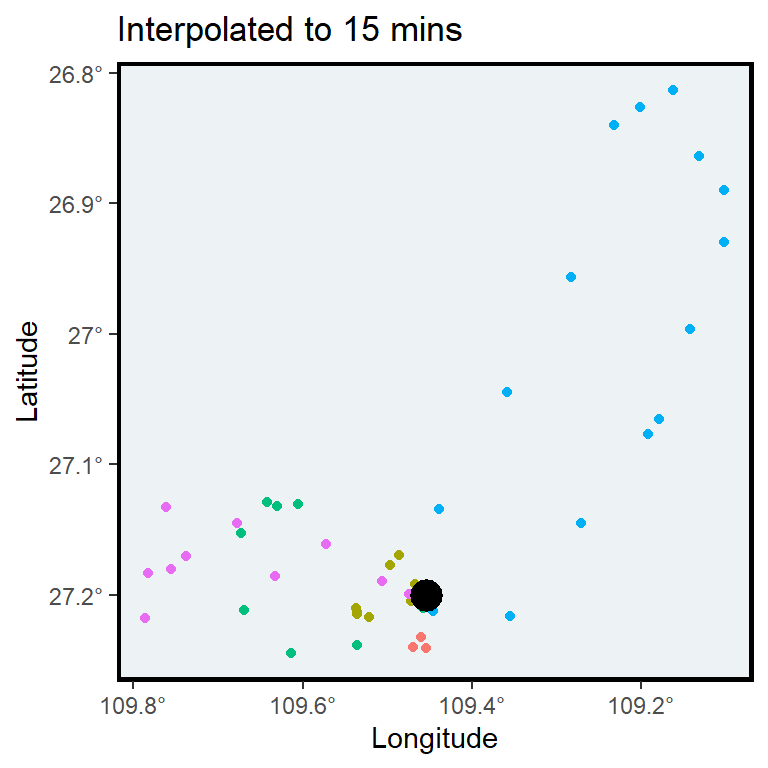

```r
Interpolated_15m<-ggplot(ID01_interpolated15m, aes(x=Longitude, y=Latitude, color=trip_number)) +
  geom_point()+
  theme_bw()+
  ggtitle('Interpolated to 15 mins')+
  theme_bw()+
  theme(legend.position='none')+
  scale_x_continuous(labels = function(x) paste0(-x, '\u00B0')) +
  scale_y_continuous(labels = function(x) paste0(-x, '\u00B0'))  +
  xlab('Longitude')+ylab('Latitude')+
  theme(
    panel.background = element_rect(fill = '#edf2f4'),
    panel.grid.major = element_blank(),
    panel.grid.minor = element_blank(),legend.position='none',
    panel.border = element_rect(colour = "black", fill=NA, size=1.5)
  )+
  geom_point(data=ID01_nest,aes(x = Longitude,y= Latitude),
             color="black", fill="black",shape=16,size=5,stroke=1.5)
Interpolated_15m
```

# Compare

Using the package **patchwork** we can see the difference side by side.

```r
library(patchwork)
```

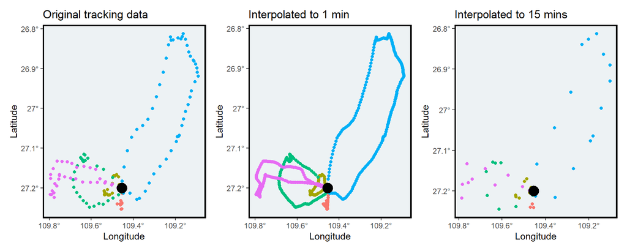

```r
Original_track+Interpolated_1m+Interpolated_15m
```

Select the interpolation interval that fits better your data.

# Further reading

To follow instructions from raw data to interpolation [check this blogpost](https://www.miriam-lerma.com/posts/2022-03-22-interpolation/).  
To access the function click [here](https://github.com/MiriamLL/sula/blob/main/R/interpolate_trips.R). You could copy and adjust the function to your data.

If you want to give it a try, there are other packages to interpolate data:\ - [crawl](https://cran.r-project.org/web/packages/crawl/crawl.pdf)  
- [adehabitatLT](https://cran.r-project.org/web/packages/adehabitatLT/adehabitatLT.pdf)  
- [trip](https://cran.r-project.org/web/packages/trip/trip.pdf)  
- [pastecs](https://cran.r-project.org/web/packages/pastecs/index.html)

# Export

# ~~~~~~~~~~~~~

# 8.August

# Remove

# Intro

When studying animals using GPSs, we often need to remove their central location. Here, I am sharing a function I created to eliminate all the locations within an area.

# Data

For the exercises, test data is from masked boobies.  
To access the data you have to install the package **sula**: devtools::install_github(“MiriamLL/sula”)

```r
#devtools::install_github("MiriamLL/sula")
library(sula)
```

This data frame contains data from 10 individuals.

```r
unique(sula::GPS_raw$IDs)
```

```
##  [1] "GPS01" "GPS02" "GPS03" "GPS04" "GPS05" "GPS06" "GPS07" "GPS08" "GPS09"
## [10] "GPS10"
```

To load it into the environment.

```r
GPS_ten<-GPS_raw
```

Plot your data

```r
library(tidyverse)
```

Here you can see all the recorded locations using the GPSs.

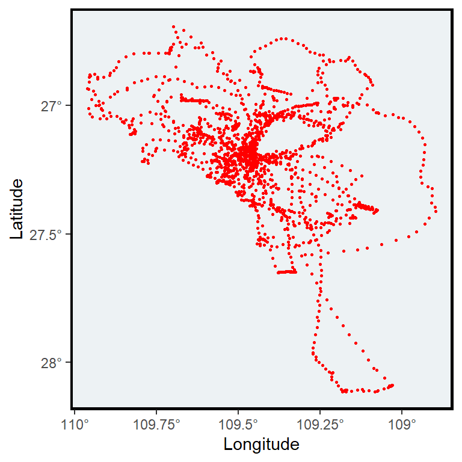

```r
Original_plot<-ggplot()+
  geom_point(data = GPS_ten,
            aes(x=Longitude,y = Latitude),color='red', size=0.5)+
  scale_x_continuous(labels = function(x) paste0(-x, '\u00B0')) +
  scale_y_continuous(labels = function(x) paste0(-x, '\u00B0'))  +
  xlab('Longitude')+ylab('Latitude')+
  theme(
    panel.background = element_rect(fill = '#edf2f4'),
    panel.grid.major = element_blank(),
    panel.grid.minor = element_blank(),legend.position='none',
    panel.border = element_rect(colour = "black", fill=NA, size=1.5)
  )
Original_plot
```

# Create a buffer

Select a location

```r
This_point<-data.frame(Longitude=-109.5,Latitude=-27.2)
```

Create a buffer

I created this function to create a buffer around a point

```r
create_buffer<-function(central_point=central_point, buffer_km=buffer_km){
  central_spatial<- sp::SpatialPoints(cbind(central_point$Longitude,central_point$Latitude))
  sp::proj4string(central_spatial)= sp::CRS("+init=epsg:4326")
  central_spatial <- sp::spTransform(central_spatial, sp::CRS("+init=epsg:4326"))
  central_spatial<-sf::st_as_sf(central_spatial)
  buffer_dist<-buffer_km*1000
  central_buffer<-sf::st_buffer(central_spatial, buffer_dist)
  return(central_buffer)
  }
```

The parameters to give are the kilometers and the central point

```r
This_buffer<-create_buffer(central_point=This_point,buffer_km=20)
```

```r
class(This_buffer)
```

```
## [1] "sf"         "data.frame"
```

Here you can see the buffer you created using the point (or central location)

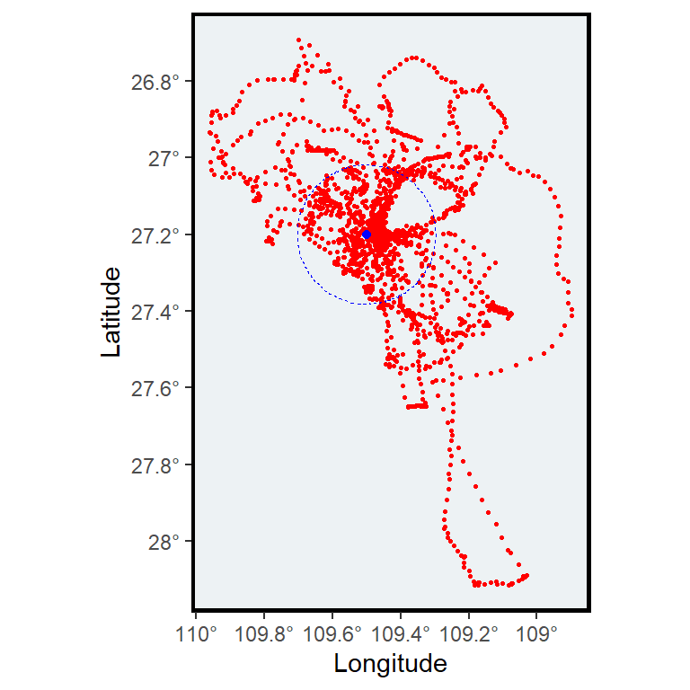

```r
Buffer_plot<-ggplot()+
  geom_point(data = GPS_ten,
            aes(x=Longitude,y = Latitude),color='red',size=0.5)+
  geom_point(data=This_point,
             aes(x=Longitude,y=Latitude),color='blue')+
  geom_sf(data=This_buffer,colour='blue', fill='transparent', linetype='dashed')+
  scale_x_continuous(labels = function(x) paste0(-x, '\u00B0')) +
  scale_y_continuous(labels = function(x) paste0(-x, '\u00B0'))  +
  xlab('Longitude')+ylab('Latitude')+
  theme(
    panel.background = element_rect(fill = '#edf2f4'),
    panel.grid.major = element_blank(),
    panel.grid.minor = element_blank(),legend.position='none',
    panel.border = element_rect(colour = "black", fill=NA, size=1.5)
  )
Buffer_plot
```

Using the function from the package **sp** you can create an spatial object using your GPS data

```r
GPS_sp <- GPS_ten
sp::coordinates(GPS_sp) <- ~Longitude + Latitude
sp::proj4string(GPS_sp) = sp::CRS("+init=epsg:4326")
GPS_sp<-sf::st_as_sf(GPS_sp)
```

```r
class(GPS_sp)
```

```
## [1] "sf"         "tbl_df"     "tbl"        "data.frame"
```

```r
class(This_buffer)
```

```
## [1] "sf"         "data.frame"
```

Here the function over identifies which location intersect with the buffer.

```r
GPS_over<-sapply(sf::st_intersects(GPS_sp,This_buffer), function(z) if (length(z)==0) NA_integer_ else z[1])
```

This information can be added as a column in the data frame.

```r
GPS_ten$In_or_out <- as.numeric(GPS_over)
```

To remove the locations that were within the buffer you can use the function **filter** and **is.na** from the package **tidyverse**

```r
GPS_without <- GPS_ten %>%
  filter(is.na(In_or_out)==TRUE)
```

Here you can see that the locations inside the buffer were removed.

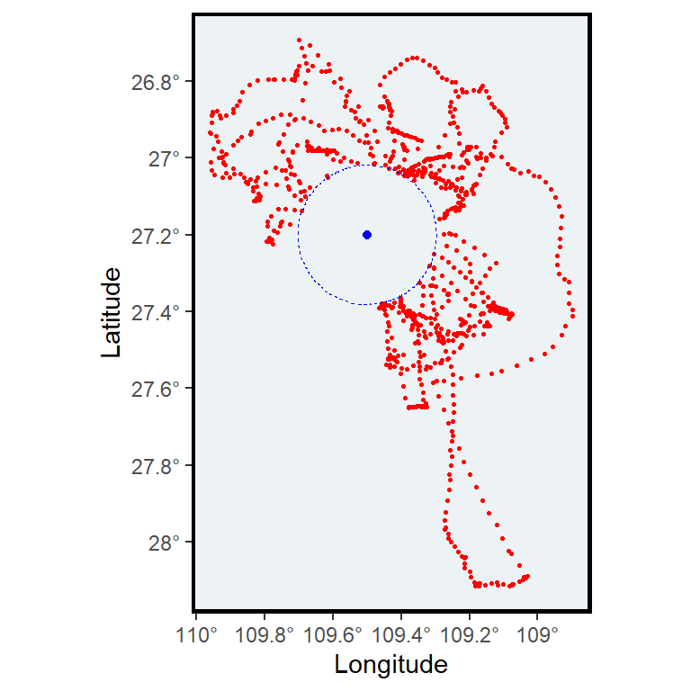

```r
Filtered_plot<-ggplot()+
  geom_point(data = GPS_without,
            aes(x=Longitude,y = Latitude),color='red',size=0.5)+
  geom_point(data=This_point,
             aes(x=Longitude,y=Latitude),color='blue')+
  geom_sf(data=This_buffer,colour='blue', fill='transparent', linetype='dashed')+
  scale_x_continuous(labels = function(x) paste0(-x, '\u00B0')) +
  scale_y_continuous(labels = function(x) paste0(-x, '\u00B0'))  +
  xlab('Longitude')+ylab('Latitude')+
  theme(
    panel.background = element_rect(fill = '#edf2f4'),
    panel.grid.major = element_blank(),
    panel.grid.minor = element_blank(),legend.position='none',
    panel.border = element_rect(colour = "black", fill=NA, size=1.5)
  )
Filtered_plot
```

This function can be used to remove all the nest locations within a distance buffer. You could also replace the polygon (here the buffer) for some land shapefiles.

# Compare

Using the package **patchwork** we can see the difference side by side.

```r
library(patchwork)
```

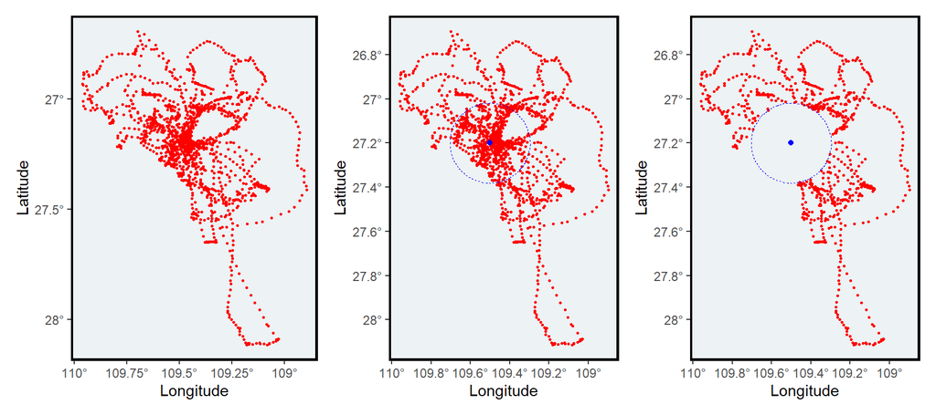

```r
Original_plot+Buffer_plot+Filtered_plot
```

# Further reading

Other functions that did the job:  
gBuffer from rgeos [deprecated](https://cran.r-project.org/web/packages/rgeos/index.html)  
Read more about [package sf](https://github.com/r-spatial/sf/wiki/migrating)

# Export

# ~~~~~~~~~~~~~

# 9.September

# Intro

This post shows an option to assign a trip number to locations of animals.  
This same method could be use to identify events on spatial data.

# Data

For the exercises, test data is from Masked boobies.

```r
#devtools::install_github("MiriamLL/sula")
library(sula)
```

This data frame contains data from 10 individuals.

```r
unique(sula::GPS_raw$IDs)
```

```
##  [1] "GPS01" "GPS02" "GPS03" "GPS04" "GPS05" "GPS06" "GPS07" "GPS08" "GPS09"
## [10] "GPS10"
```

Using functions from the package **tidyverse**, one of the individuals can be selected.

```r
library(tidyverse)
```

```r
GPS_one<-GPS_raw %>% filter(IDs=='GPS08')
```

The original data can be checked using functions from the package **ggplot2**.

```r
library(ggplot2)
```

In the plot all locations are presented, but events can not be identify yet.

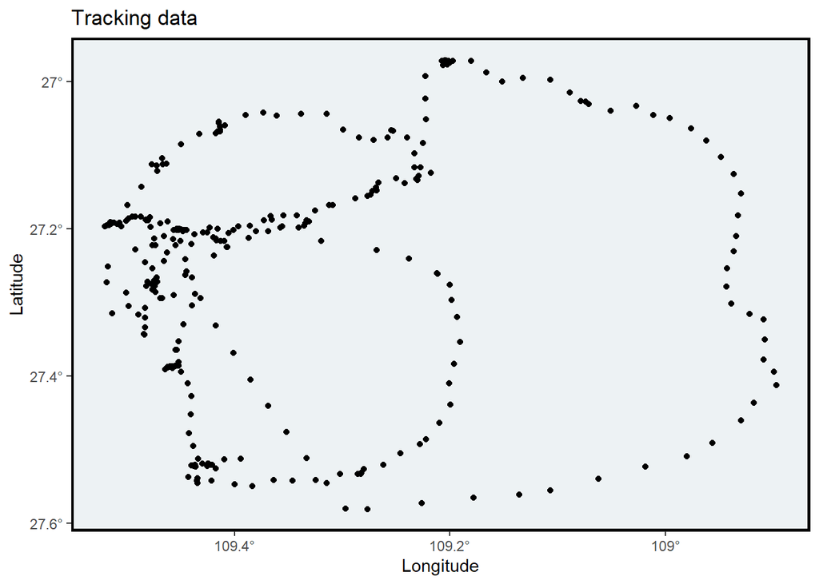

```r
Plot_original<-ggplot(GPS_one, aes(x=Longitude, y=Latitude)) +
  geom_point()+
  scale_x_continuous(labels = function(x) paste0(-x, '\u00B0')) +
  scale_y_continuous(labels = function(x) paste0(-x, '\u00B0'))  +
  ggtitle('Tracking data')+xlab('Longitude')+ylab('Latitude')+
  theme_bw()+
  theme(
    legend.position='none',
    panel.background = element_rect(fill = '#edf2f4'),
    panel.grid.major = element_blank(),
    panel.grid.minor = element_blank(),
    panel.border = element_rect(colour = "black", fill=NA, size=1.5))
Plot_original
```

# Remove central locations

An event would be defined as each time the animal leaves its central location.

The information about the central location is needed.

```r
Central_location<-data.frame(Longitude=-109.4531, Latitude=-27.20097)
```

The locations are to be transform into spatial data.

```r
GPS_spatial <- GPS_one
sp::coordinates(GPS_spatial) <- ~Longitude + Latitude
sp::proj4string(GPS_spatial) = sp::CRS("+init=epsg:4326")
GPS_spatial<-sf::st_as_sf(GPS_spatial)
```

The buffer function is explained in the previous [post](https://www.miriam-lerma.com/posts/2024-08-01-removelocs/).  
The function uses the central location to create a buffer.  
A number “1” shows that the location is inside the 1 km buffer and an NA that is outside the buffer.  
The information is added on a column in the data frame.

```r
create_buffer<-function(central_point=central_point, buffer_km=buffer_km){
  central_spatial<- sp::SpatialPoints(cbind(central_point$Longitude,central_point$Latitude))
  sp::proj4string(central_spatial)= sp::CRS("+init=epsg:4326")
  central_spatial <- sp::spTransform(central_spatial, sp::CRS("+init=epsg:4326"))
  central_spatial<-sf::st_as_sf(central_spatial)
  buffer_dist<-buffer_km*1000
  central_buffer<-sf::st_buffer(central_spatial, buffer_dist)
  return(central_buffer)
  }
This_buffer<-create_buffer(central_point=Central_location,buffer_km=1)
GPS_over<-sapply(sf::st_intersects(GPS_spatial,This_buffer), function(z) if (length(z)==0) NA_integer_ else z[1])
GPS_one$trip <- as.numeric(GPS_over)
```

The NAs (when the animal is outside the buffer) can be replaced for a 0.  
This is not strictly necessary but facilitates the interpretation of the column.

```r
GPS_one$trip[is.na(GPS_one$trip)] <- 0
```

Alternatively, text can be added.

```r
GPS_one$trip <- gsub("1", "At_central_locations", GPS_one$trip)
GPS_one$trip <- gsub("0", "At_trip", GPS_one$trip)
```

# Assign trip number

To assign the trip number, the first step was adding a new column with a sequential number.

```r
GPS_one$sequential_number<-as.integer(paste(seq(1:as.numeric(nrow(GPS_one)))))
```

Afterwards, all the locations inside the central locations were removed.

```r
GPS_trips<-subset(GPS_one, GPS_one$trip == "At_trip")
```

By removing the locations inside the central locations, we end up with gaps in the sequence number.  
Here, I added a number of event everytime that the sequence was broken.

```r
GPS_trips$trip_number <- (cumsum(c(1L, diff(GPS_trips$sequential_number)) != 1L))+ 1
```

In case there might be more than ten trips, adding more zeros using the function **str_pad** might be useful.

```r
GPS_trips$trip_number <- stringr::str_pad(GPS_trips$trip_number ,  2, pad = "0")
```

For easier interpretation, text can be added.

```r
GPS_trips$trip_number<-paste0("Trip_", GPS_trips$trip_number )
```

Using the function **unique** the number of events (or trips) can be checked.

```r
unique(GPS_trips$trip_number)
```

```
## [1] "Trip_01" "Trip_02" "Trip_03" "Trip_04" "Trip_05" "Trip_06"
```

# Plot

The different events can now be easily observed by adding the argument **color=trip_number** in the plot.

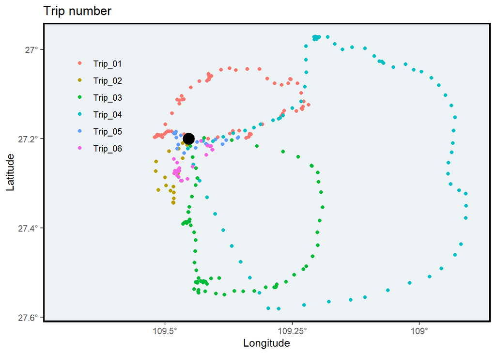

```r
Plot_trips<-ggplot(GPS_trips, aes(x=Longitude, y=Latitude, color=trip_number)) +
  geom_point()+
  geom_point(data=Central_location,aes(x = Longitude,y= Latitude),
             color="black", fill="black",shape=16,size=5,stroke=1.5)+
  theme_bw()+
  scale_x_continuous(limits=c(-109.7,-108.9),labels = function(x) paste0(-x, '\u00B0')) +
  scale_y_continuous(labels = function(x) paste0(-x, '\u00B0'))  +
  ggtitle('Trip number')+xlab('Longitude')+ylab('Latitude')+labs(color='')+
  theme(
    panel.background = element_rect(fill = '#edf2f4'),
    panel.grid.major = element_blank(),
    panel.grid.minor = element_blank(),
    panel.border = element_rect(colour = "black", fill=NA, size=1.5),
    legend.background = element_rect(colour = "transparent", fill = "transparent"),
    legend.position = c(0.12,0.75))
Plot_trips
```

# Further reading

Functions **count_trips** from the package sula can be used to run loops.

# Export

# ~~~~~~~~~~~~~

# 10.October

# Distance points

# Intro

Calculate distance between points between consecutive locations.  
One of the uses in animal movements it to calculate how much distance an animal covers on one trip.

# Data

For the exercises, test data is from Masked boobies.

```r
#devtools::install_github("MiriamLL/sula")
library(sula)
```

This data frame contains data from one individual.  
It has the column Longitude, Latitude and trip_number.

```r
GPS_edited<-sula::GPS_edited
```

Load the package **tidyverse**

```r
library(tidyverse)
```

Select one of the trips from this individual.

```r
GPS_trip <- GPS_edited %>% filter(trip_number=='trip_4')
```

Using the function **geom_path** you can plot the trajectory.

```r
library(ggspatial)
```

Add the annotation layer to see the scale.

```
## Using plotunit = 'm'
```

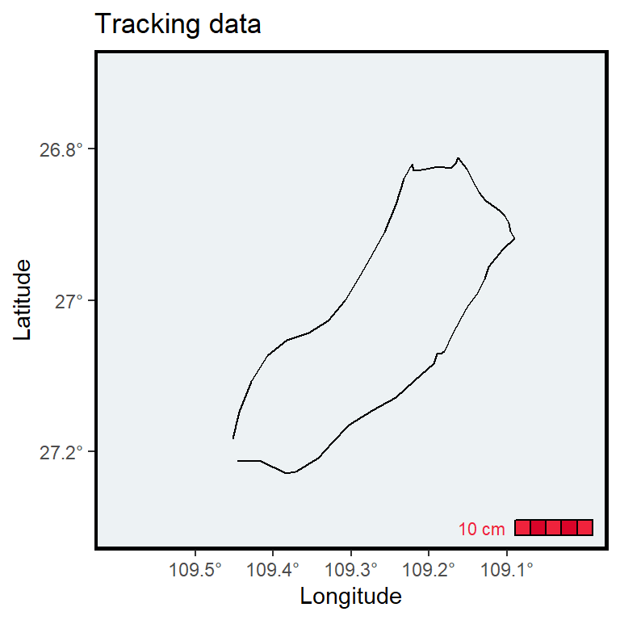

```r
ggplot(GPS_trip, aes(x=Longitude, y=Latitude)) +
  geom_path()+
  scale_x_continuous(limits=c(-109.6,-109.0),breaks=c(-109.5,-109.4,-109.3,-109.2,-109.1),labels = function(x) paste0(-x, '\u00B0')) +
  scale_y_continuous(limits=c(-27.3,-26.7),labels = function(x) paste0(-x, '\u00B0'))  +
  ggtitle('Tracking data')+xlab('Longitude')+ylab('Latitude')+
  theme_bw()+
  theme(
    legend.position='none',
    panel.background = element_rect(fill = '#edf2f4'),
    panel.grid.major = element_blank(),
    panel.grid.minor = element_blank(),
    panel.border = element_rect(colour = "black", fill=NA, size=1.5))+
    annotation_scale(location = "br",bar_cols = c("#ef233c", "#d90429"),text_col = '#ef233c')
```

# Convert to spatial

Convert to spatial object to assign a reference system.

```r
GPS_spatial <- GPS_trip[, c("Longitude", "Latitude")]
GPS_spatial <- sp::SpatialPointsDataFrame(coords = GPS_spatial,data = GPS_trip)
sp::proj4string(GPS_spatial) = sp::CRS("+init=epsg:4326")
```

This function calculates distance between consecutive points.

```r
GPS_dist <- sapply(2:nrow(GPS_spatial), function(i) {geosphere::distm(GPS_spatial[i - 1, ], GPS_spatial[i,])})
```

To add it back to the data frame consider that the first point is missing. To solve this add a zero or an NA.

```r
GPS_dist<- c(0, GPS_dist)
```

It would show in meters, divide by 1000 to show as kilometers, the function **round** helps to transform to only two decimals.

```r
GPS_trip$distances <- round(GPS_dist/1000, 2)
```

# Plot

To plot as an spatial object (and get the scale correct) use functions from the package **sf**.

```r
library(sf)
```

```r
GPS_sf <- st_as_sf(GPS_spatial)
```

Here the scale is showed correctly.

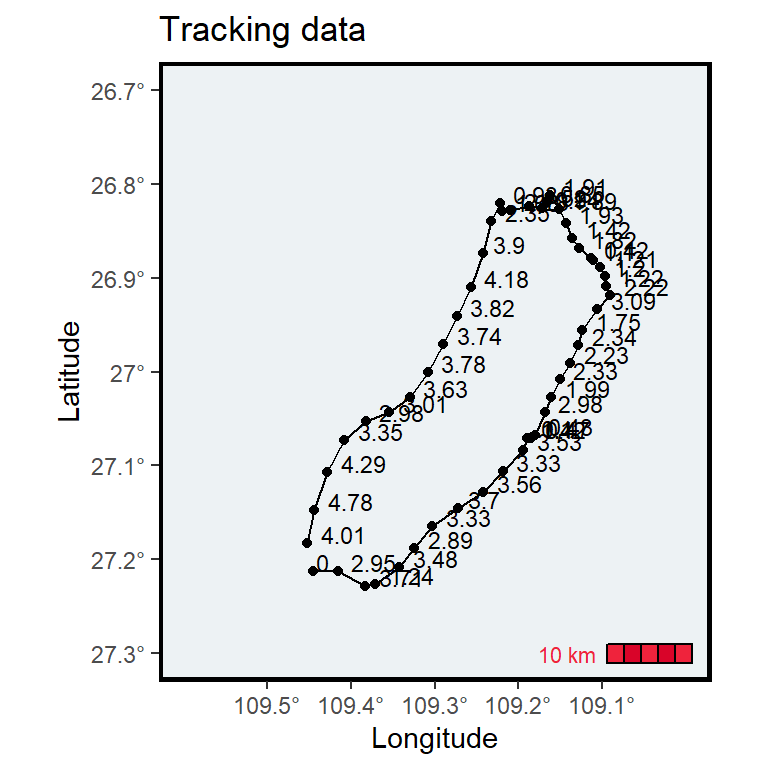

```r
ggplot(GPS_sf)+
  geom_sf()+
  geom_point(data=GPS_trip, aes(x=Longitude,y=Latitude))+
  geom_text(data=GPS_trip, aes(x=Longitude,y=Latitude,label=distances),hjust=-0.3, vjust=0, size=3)+
  geom_path(data=GPS_trip, aes(x=Longitude,y=Latitude))+
  annotation_scale(location = "br",bar_cols = c("#ef233c", "#d90429"),text_col = '#ef233c')+
  scale_x_continuous(limits=c(-109.6,-109.0),breaks=c(-109.5,-109.4,-109.3,-109.2,-109.1),labels = function(x) paste0(-x, '\u00B0')) +
  scale_y_continuous(limits=c(-27.3,-26.7),labels = function(x) paste0(-x, '\u00B0'))  +
  ggtitle('Tracking data')+xlab('Longitude')+ylab('Latitude')+
  theme_bw()+
  theme(
    legend.position='none',
    panel.background = element_rect(fill = '#edf2f4'),
    panel.grid.major = element_blank(),
    panel.grid.minor = element_blank(),
    panel.border = element_rect(colour = "black", fill=NA, size=1.5))
```